# Coronavirus v Čechách

# Základní statistiky

## Přehled

Základní přehled (testy)

| Datum | Přírustkový počet testů | Kumulativní počet testů | Pozitivita testů (v %) |
| --- | --- | --- | --- |
| 2020-10-19 | 31115 | 1845318 | 25.96 |
| 2020-10-20 | 40544 | 1885862 | 29.56 |
| 2020-10-21 | 45030 | 1930892 | 33.24 |
| 2020-10-22 | 46364 | 1977256 | 30.53 |
| 2020-10-23 | 44215 | 2021471 | 34.50 |

Základní přehled (nákaza)

| Datum | Přírustkový počet nakažených | Kumulativní počet nakažených | Kumulativní počet vyléčených | Kumulativní počet úmrtí |
| --- | --- | --- | --- | --- |
| 2020-10-19 | 8076 | 181965 | 90098 | 1607 |
| 2020-10-20 | 11984 | 193949 | 90656 | 1700 |
| 2020-10-21 | 14968 | 208917 | 91084 | 1821 |
| 2020-10-22 | 14155 | 223072 | 91491 | 1924 |
| 2020-10-23 | 15252 | 238324 | 91807 | 2017 |

Aktuálně hospitalizovaní: `5314`

Podíl nakažených s těžkým průběhem: `3.49`%

## Testy

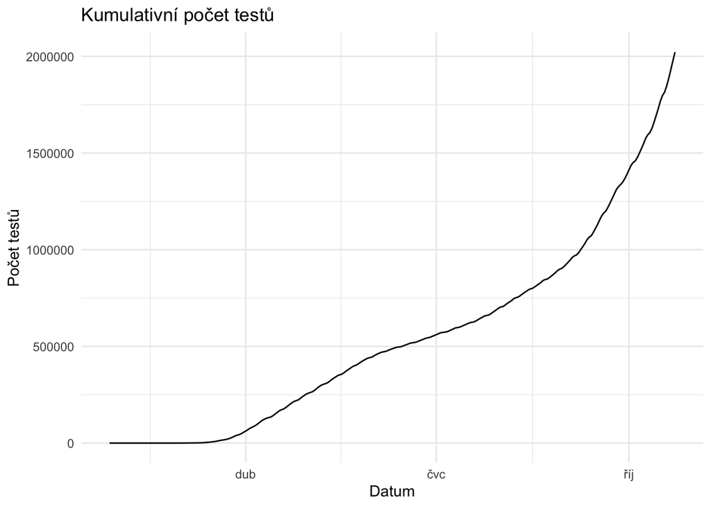

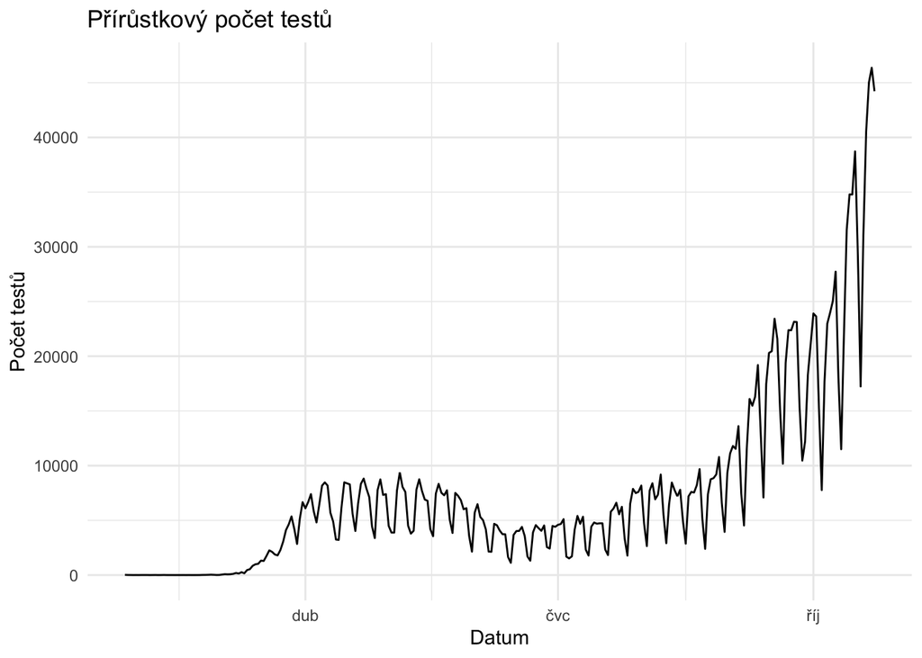

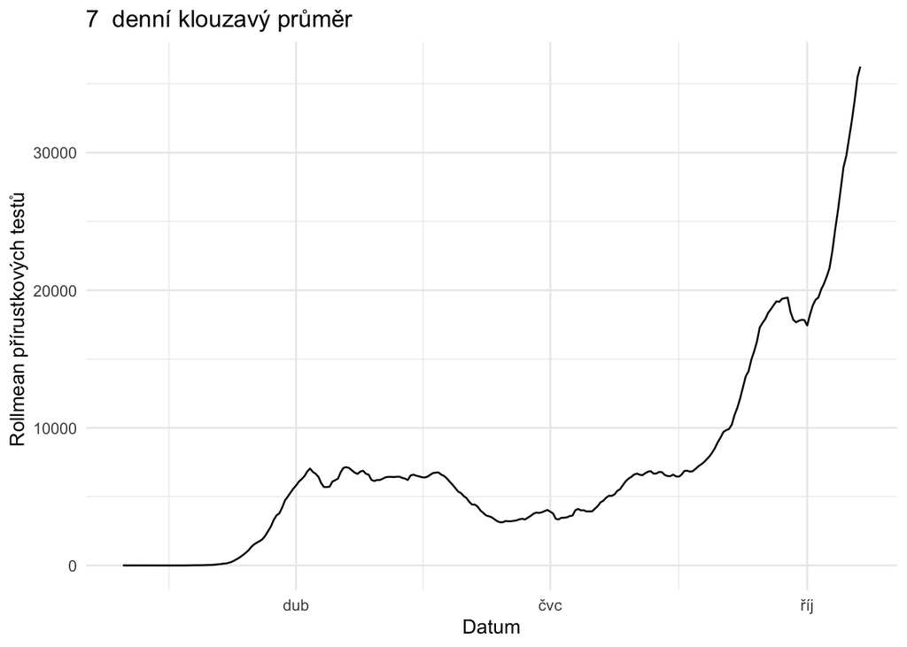

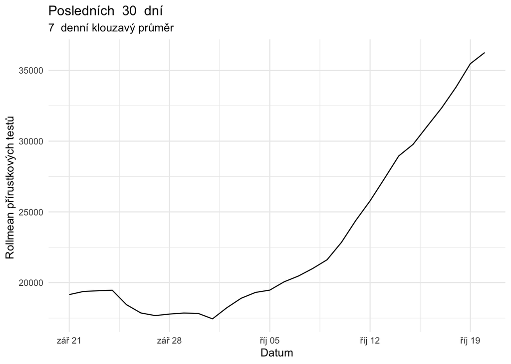

## Pozitivní případy

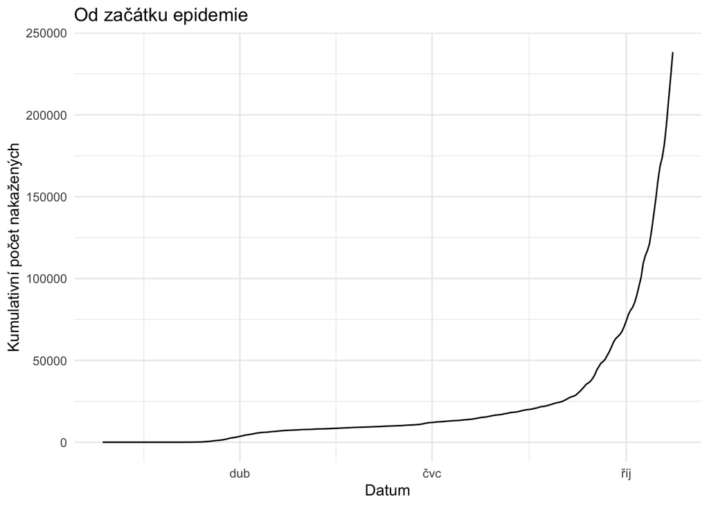

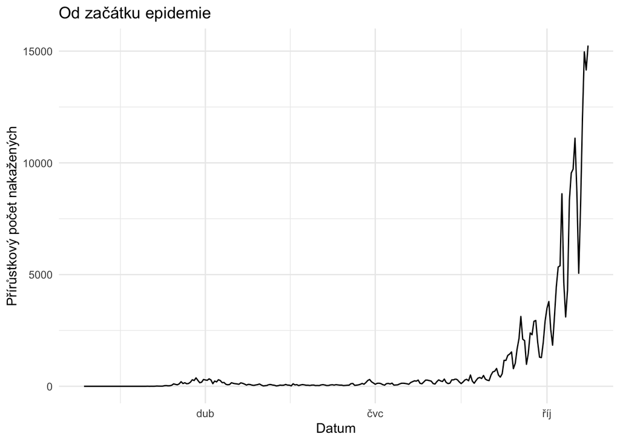

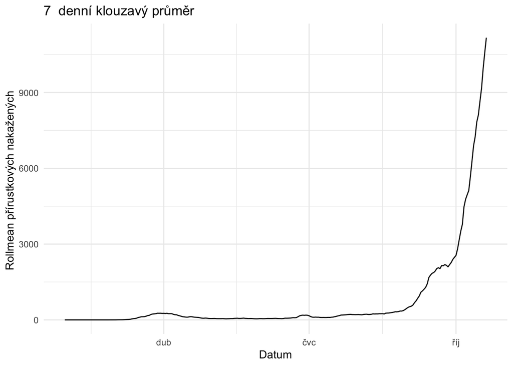

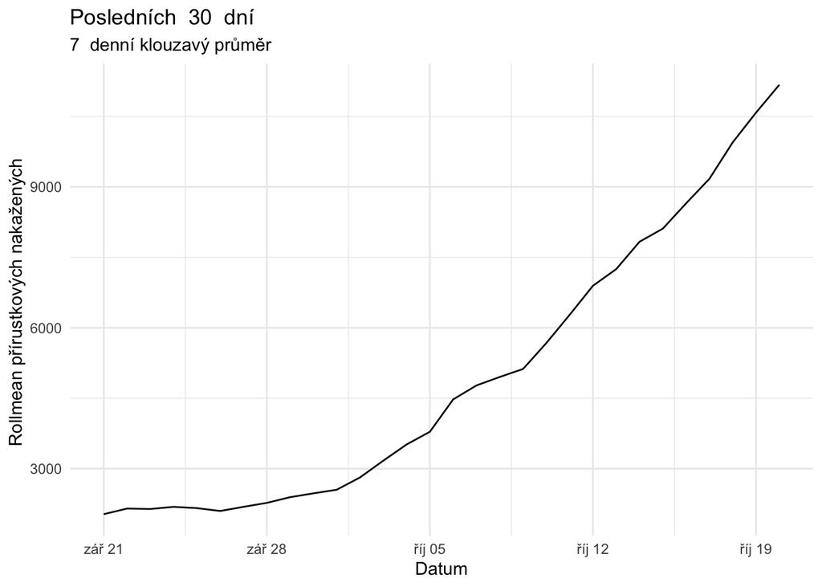

## Podíl pozitivních testů

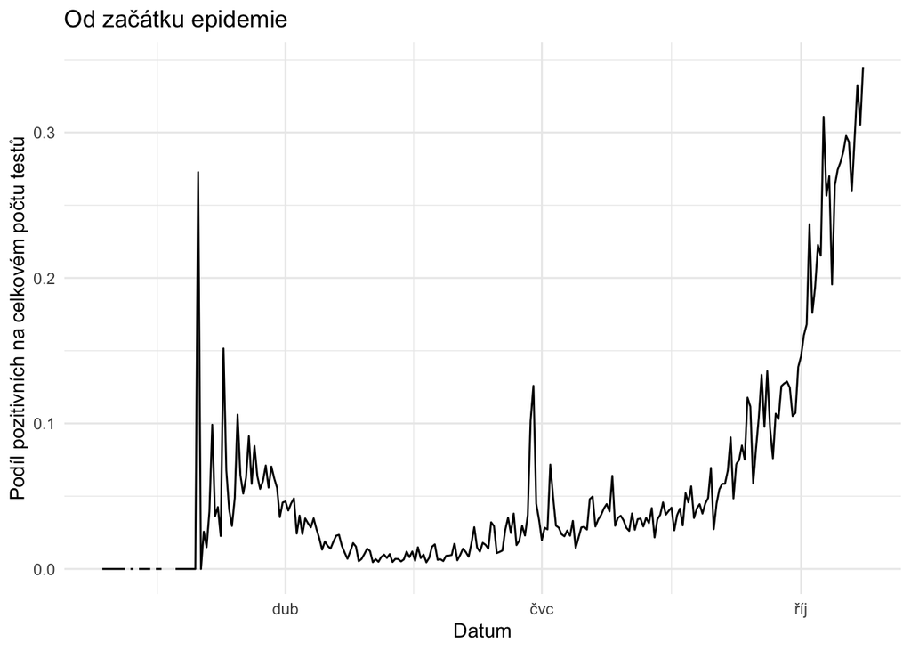

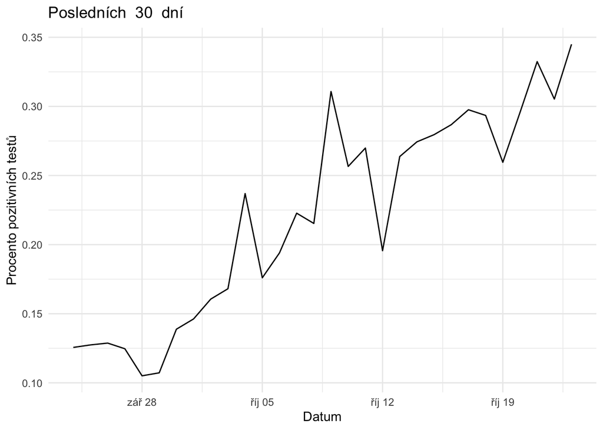

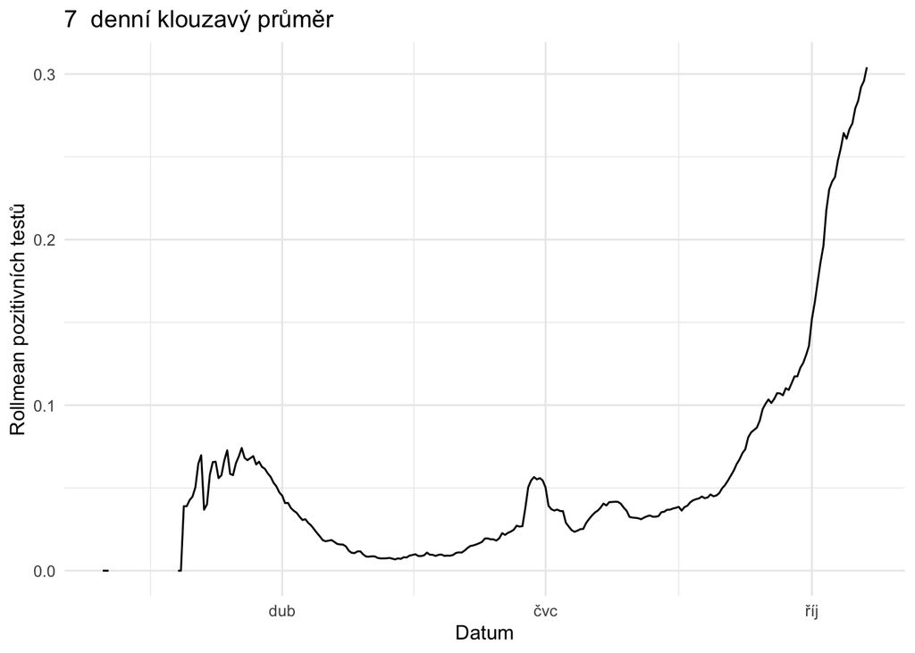

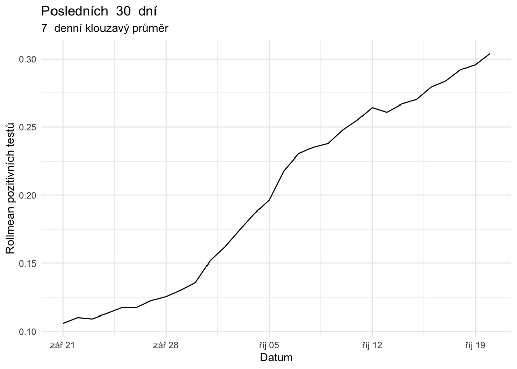

Podíl pozitivních testů na celkovém počtu od začátku epidemie je `11.79` %.

Podíl pozitivních testů na celkovém počtu za posledních 30 dní je `24.161` %.

# Modely

## Linearní model

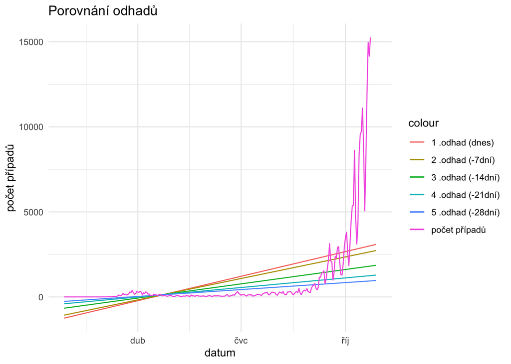

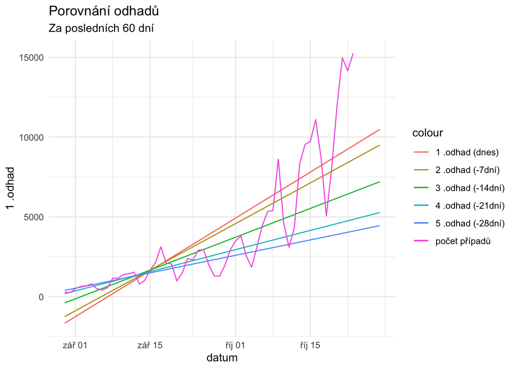

### Data (Lineární model)

#### Od začátku epidemie

Podle lineárního modelu bychom tímto tempem měli dne `2020-10-28` podle

- 1. odhadu `3087` nakažených denně
- 2. odhadu `2724` nakažených denně
- 3. odhadu `1857` nakažených denně
- 4. odhadu `1281` nakažených denně
- 5. odhadu `960` nakažených denně

#### Za posledních `60` dní

Podle lineárního modelu bychom tímto tempem měli dne `2020-10-28` podle

- 1. odhadu `10485` nakažených denně
- 2. odhadu `9498` nakažených denně
- 3. odhadu `7205` nakažených denně
- 4. odhadu `5272` nakažených denně
- 5. odhadu `4451` nakažených denně

## Kvadratický model

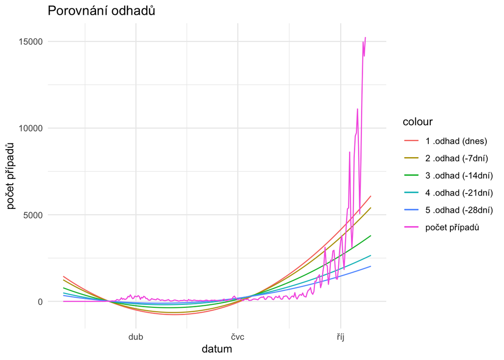

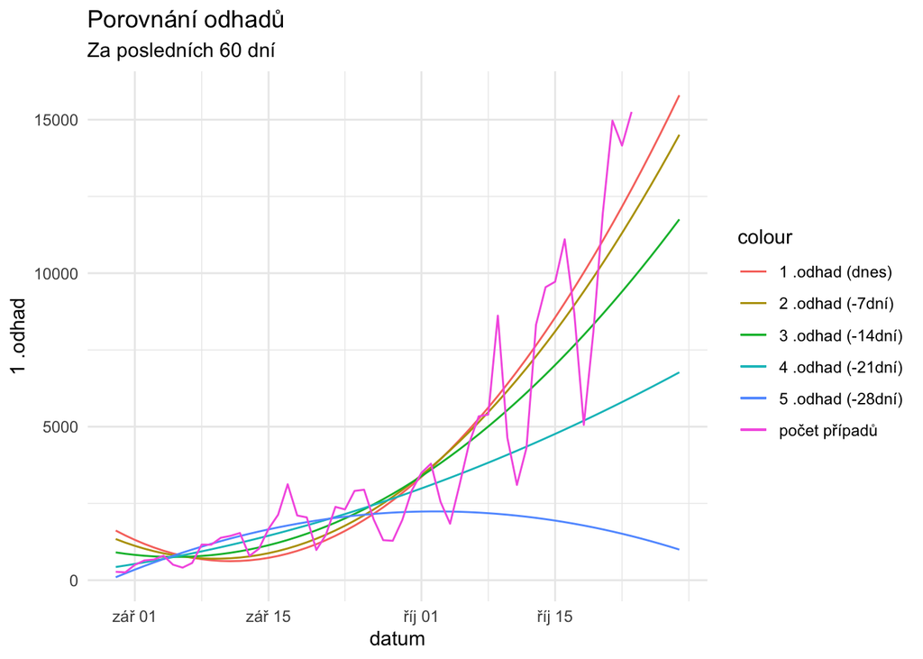

### Data (Kvadratický model)

#### Od začátku epidemie

Podle kvadratického modelu bychom tímto tempem měli dne `2020-10-28` podle

- 1. odhadu `6092` nakažených denně
- 2. odhadu `5417` nakažených denně
- 3. odhadu `3801` nakažených denně
- 4. odhadu `2658` nakažených denně
- 5. odhadu `2030` nakažených denně

#### Za posledních `60` dní

- 1. odhadu `15796` nakažených denně
- 2. odhadu `14508` nakažených denně
- 3. odhadu `11754` nakažených denně
- 4. odhadu `6770` nakažených denně
- 5. odhadu `998` nakažených denně

## Exponential model

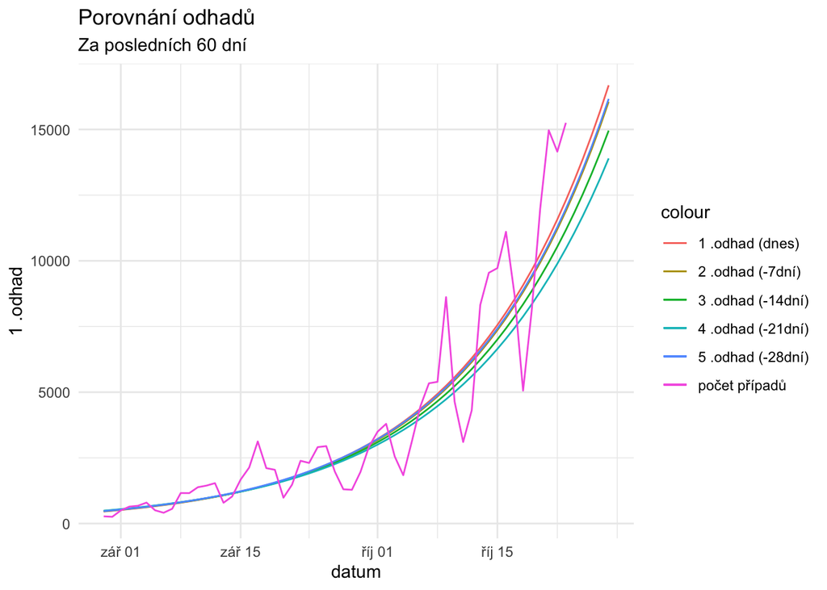

### Data (Exponential model)

#### Za posledních `60` dní

Podle exponencionálního modelu bychom tímto tempem měli dne `2020-10-28` podle

- 1. odhadu `16682` nakažených denně
- 2. odhadu `16055` nakažených denně
- 3. odhadu `14956` nakažených denně
- 4. odhadu `13898` nakažených denně
- 5. odhadu `16163` nakažených denně

Podle exponencionálního modelu bychom tímto tempem měli dnes dne `2020-10-24` podle

- 1. odhadu `13075` nakažených denně
- 2. odhadu `12630` nakažených denně
- 3. odhadu `11843` nakažených denně
- 4. odhadu `11076` nakažených denně
- 5. odhadu `12720` nakažených denně

# SIR MODELY

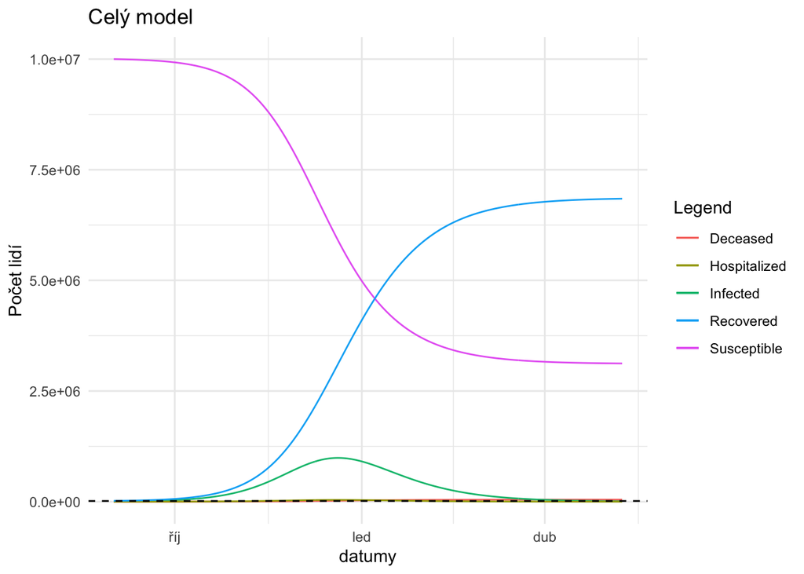

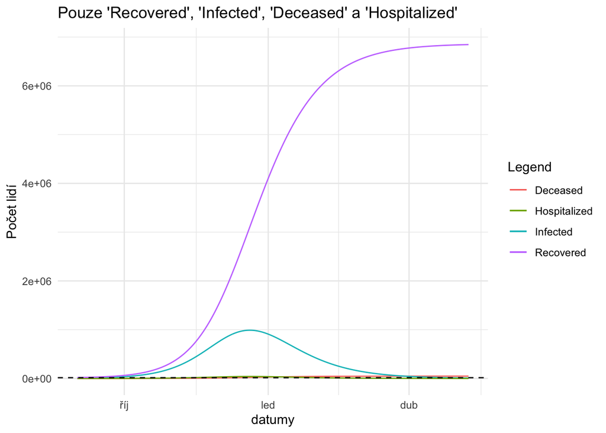

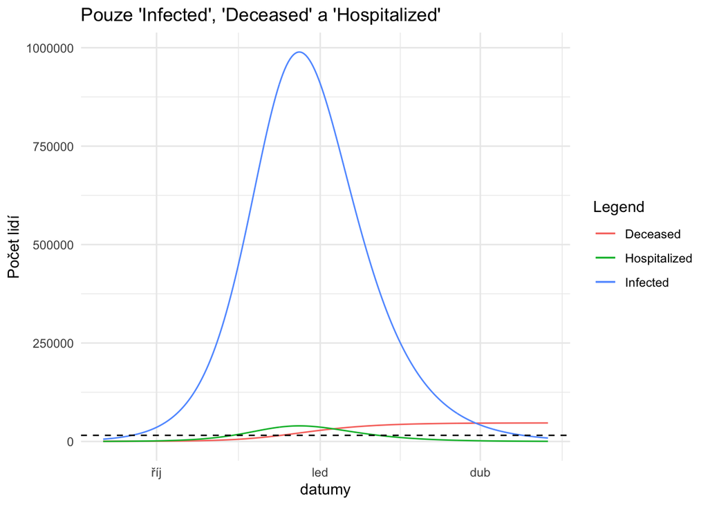

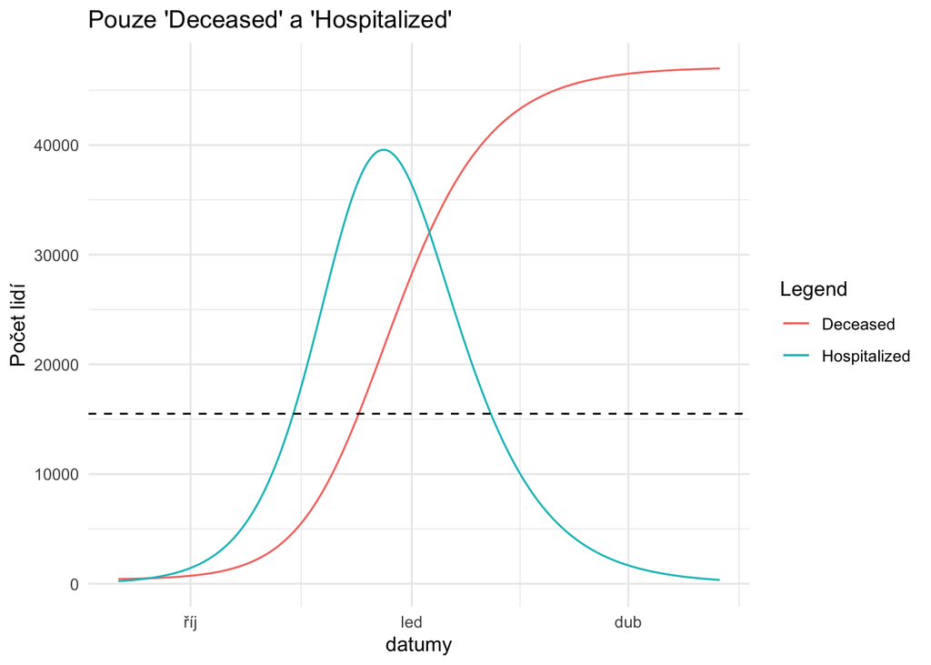

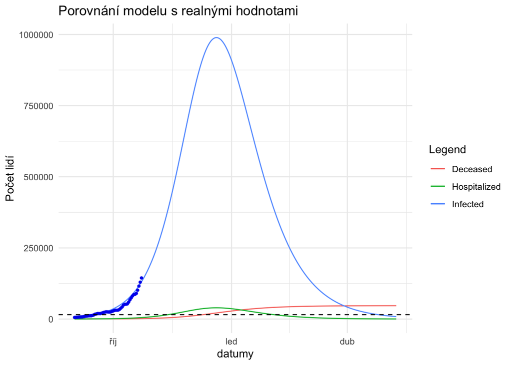

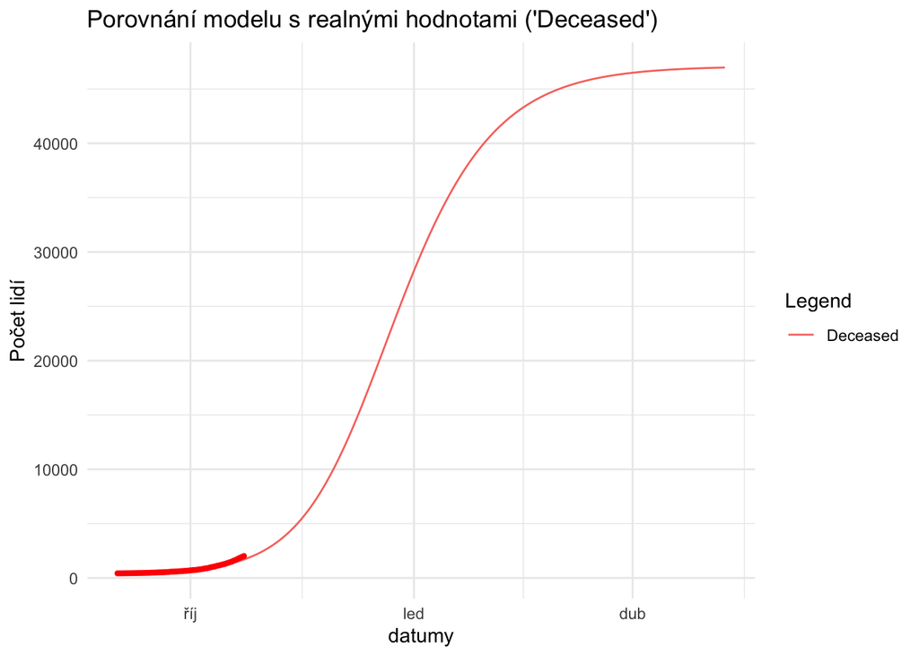

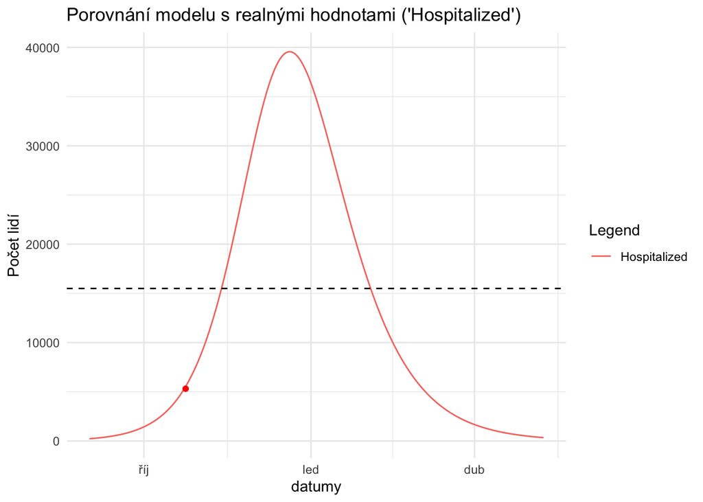

## Informace

`Peak nastane dne 2020-12-20 s počtem nakažených rovnu 989166 a aktuálním počtem hospitalizovných v nemocnicích 39567 lidí.`

`Kapacita nemocnic, která je stanovena na 15500 lůžek, bude při momentálním trendu překročena dne 2020-11-13`

`Celkově Covid-19 prodělá 6846520`

`Počet umrtí se zastaví na čísle 46980`

`Momentální hodnota rho je 1.705`

# Informace

Update proběhl `2020-10-24 22:49:57`.

Poslední data jsou z `2020-10-23` ze stránek ministerstva zdravotnictví ČR (https://onemocneni-aktualne.mzcr.cz/covid-19)